# Final Project - Jason Cabardo

## Question 9

Can we cluster houses based off of sales price and the square feet of the living area/lot of the house?

```python
features = ["price", "sqft_living","sqft_lot"]

X_gm = house[features]

z = StandardScaler()

X_gm[features] = z.fit_transform(X_gm)
```

```python
EM = GaussianMixture(n_components = 3)

EM.fit(X_gm)
```

```
GaussianMixture(n_components=3)
```

```python
cluster = EM.predict(X_gm)
cluster
```

```
array([0, 0, 0, ..., 0, 0, 0])
```

```python
silhouette_score(X_gm, cluster)
```

```
0.42632621159027
```

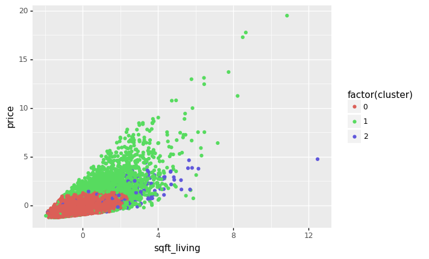

```python
X_gm["cluster"] = cluster

(ggplot(X_gm, aes(x = "sqft_living", y = "price", color = "factor(cluster)")) + geom_point())
```

-The red cluster in the bottom left shows houses that are low in price and low in both sqft_lot and sqft_living area. These are likely cheap properties that are very small and minimal for lower class citizens.

-The blue cluster shows real estate with a way more space in sqft_lot and sqft_living area for a little more of the price. These can be small houses rather than meager apartments/condos.

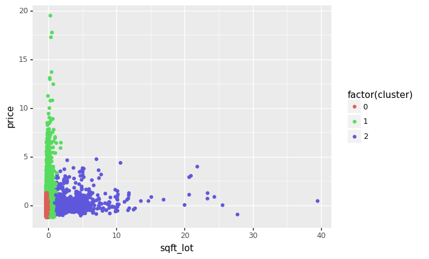

```python
X_gm["cluster"] = cluster

(ggplot(X_gm, aes(x = "sqft_lot", y = "price", color = "factor(cluster)")) + geom_point())
```

-The red cluster in the bottom left shows houses that are low in price and low in both sqft_lot and sqft_living area. These are likely cheap properties that are very small and minimal for lower class citizens.

-The blue cluster shows real estate with a way more space in sqft_lot and sqft_living area for a little more of the price. These can be small houses rather than meager apartments/condos.

Yes, we are able to cluster houses based off of sales price and the square feet of the living area/lot of the house. We will utilize a Gaussian Mixture Model. As there were no explicitly labeled groups in this data, we wanted to confirm my assumptions about what types of groups exist and identify unknown groups in this King County House dataset. Gaussian is an iterative process to create "k" groups from this property data based on the values of the variables, and through this, we are able to see the clusters converge to a particular membership so that we can identify different groups in the data. When clustering my data, we only want to use 3 features for better visualization in two/three dimensions. We will decide to cluster the data utilizing only “price”, "Sqft_lv", and “Sqft_lot”, to assign membership for this King County House dataset. Gaussian assigns each data point a probability of being assigned to each cluster. So rather it being a hard assignment and assuming that all clusters are spherical with the same variance in every direction; Gaussian has a soft-probabilistic assignment that allows more elliptical shapes.

-The red cluster in the bottom left shows houses that are low in price and low in both sqft_lot and sqft_living area. These are likely cheap properties that are very small and minimal for lower class citizens.

-The blue cluster shows real estate with a way more space in sqft_lot and sqft_living area for a little more of the price. These can be small houses rather than meager apartments/condos.

## Question 14

Taking some of the coefficients and putting them to zero, is the model as accurate when cutting out some variables (dimensionality reduction)?

```python
feat = ["bedrooms", "bathrooms", "sqft_living", "sqft_lot", "floors", "waterfront", "condition", "grade"]
X = house[feat]
y = house["price"]

X_train, X_test, y_train, y_test = train_test_split(X,y, test_size = 0.3)

z = StandardScaler()

X_train[feat] = z.fit_transform(X_train[feat])
X_test[feat] = z.transform(X_test[feat])

X_train.head()
```

|  | bedrooms | bathrooms | sqft_living | sqft_lot | floors | waterfront | condition | grade |
| --- | --- | --- | --- | --- | --- | --- | --- | --- |
| 17458 | 0.677562 | 0.822132 | -0.196021 | -0.215319 | -0.908094 | -0.084793 | -0.640250 | -0.565135 |
| 20652 | 1.747141 | 0.498621 | 0.740073 | -0.215319 | 0.942590 | -0.084793 | -0.640250 | 0.293636 |
| 20406 | 0.677562 | 0.822132 | 0.195832 | -0.222275 | 0.942590 | -0.084793 | -0.640250 | 0.293636 |
| 10189 | -0.392016 | -1.442446 | -0.631414 | -0.224633 | -0.908094 | -0.084793 | 2.437222 | -1.423907 |
| 13973 | -1.461594 | -1.442446 | -1.132116 | -0.261537 | -0.908094 | -0.084793 | -0.640250 | -0.565135 |

```python
lr = LinearRegression()
lr.fit(X_train,y_train)

print("TRAIN: ", mean_absolute_error(y_train, lr.predict(X_train)))
print("TEST : ", mean_absolute_error(y_test, lr.predict(X_test)))
```

```
TRAIN:  156105.3468526336
TEST :  155561.81365400966
```

```python
lsr = Lasso()

lsr.fit(X_train,y_train)

print("TRAIN: ", mean_absolute_error(y_train, lsr.predict(X_train)))
print("TEST : ", mean_absolute_error(y_test, lsr.predict(X_test)))
```

```
TRAIN:  156105.18454694803
TEST :  155561.60856882637
```

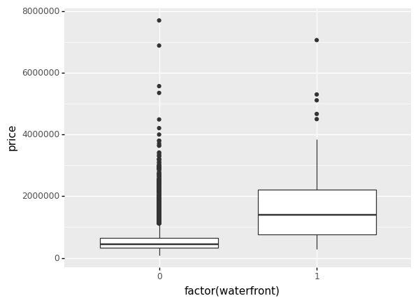

```python
(ggplot(house, aes(x = "factor(waterfront)", y = "price"))+ geom_boxplot())
```

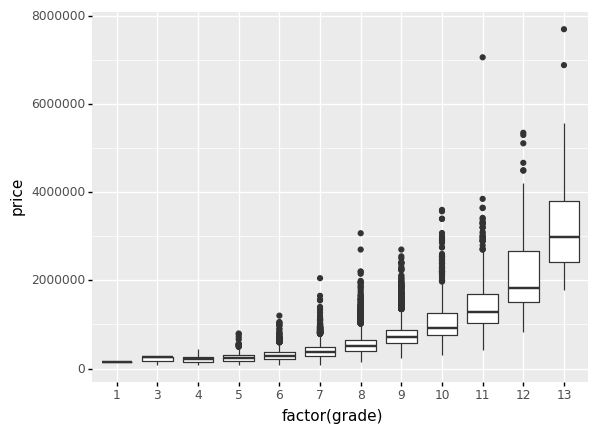

```python
(ggplot(house, aes(x = "factor(grade)", y = "price"))+ geom_boxplot())
```

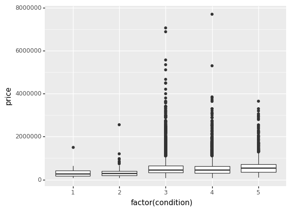

```python
(ggplot(house, aes(x = "factor(condition)", y = "price"))+ geom_boxplot())
```

By utilizing Lasso, it pushes the small coefficients to be exactly zero. This is a way of improving our model generalization - avoiding overfitting by assuming the small relationships are actually just noise from our sample and do not apply to the population of our data as a whole. In this way, we can choose which variables to include in the model. Lasso has slightly less error between the train and test set. However, comparing Lasso where it essentially removes variables from the model to Linear Regression where it accounts for all of them... it is very similar and probably just as accurate.